# Outside Item Memory

> This notebook focuses on item memory outside the rooms.

# 1 Overview of the data

The rooms were separated into *Familiar* and *Novel* groups. Participants explored the *Familiar* group at the beginning of the experiment. In the encoding task, they visisted both *Familiar* and *Novel* groups. Their item memory (i.e., in which room they saw the item) was tested in the memory test the next day of the encoding task. **Novelty benefits** on the item memory are examined by comparing the memory performance between the *Familiar* and *Novel* groups.

Participants were also asked to rate how curious they felt about the room. The higher the rating is means they felt more curious about the room. Item memory as a function of curiosity rating was also examined for **curiosity benefits**.

Questionnaires on personal traits regarding curiosity were also administered to participants before the encoding task (i.e., PC and EC). Scores on these questionnaires might be able to predict the item memory or its relationship with curiosity rating.

In the encoding task, there were 6 objects in each room. It is possbile that the item memory for the object to some extent depends on the order in which the object was seen. For example, it may be easier to remember where the first and last objects were seen as compared to those in the middle.

# 2 Visual inspection of the data

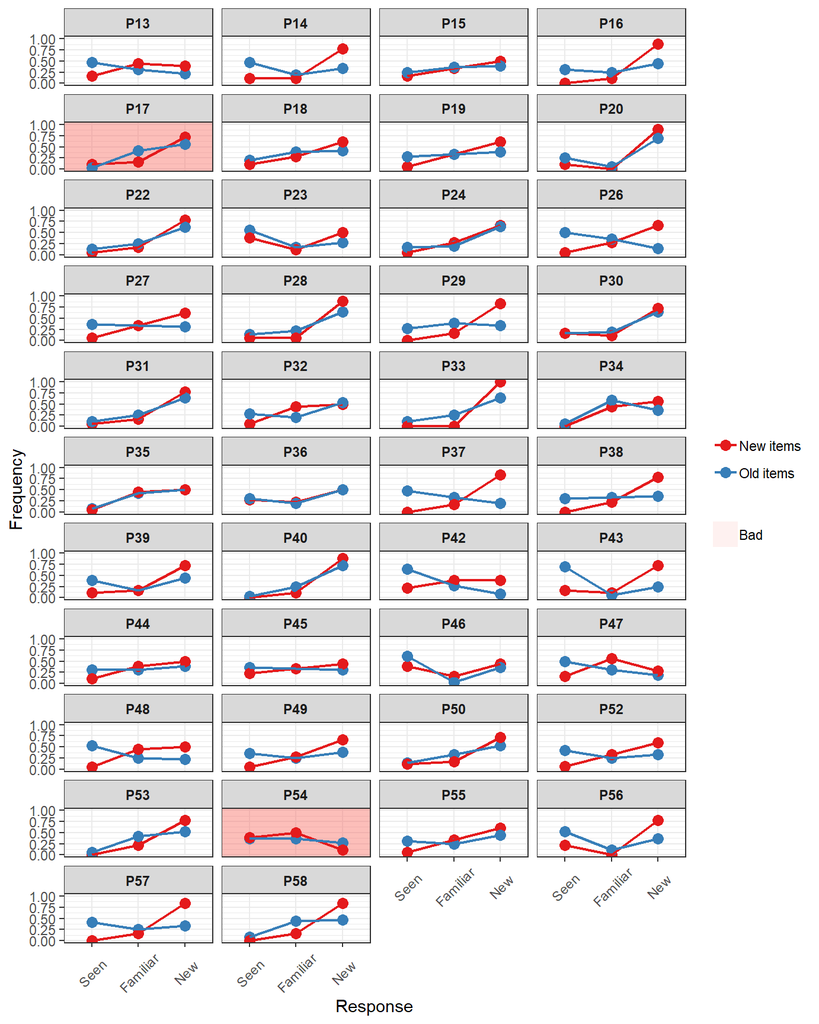

Figure 1. Response frequency for new and old items respectively for each individual participant.

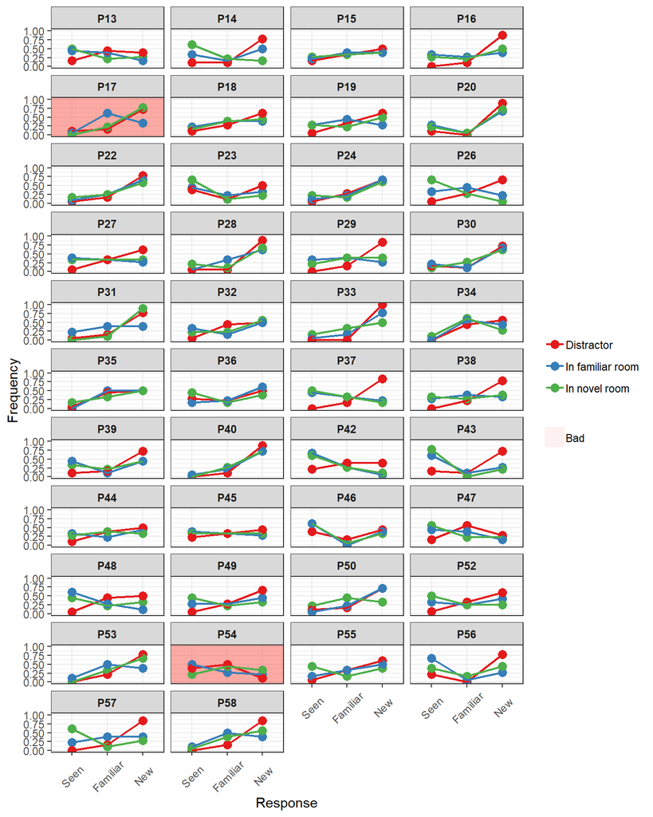

Figure 2. Response frequency for new and old items respectively for each Familiar/Novel group and each individual participant.

# 3 Novelty Benefits

We hypothesised that the memory for the items outside the rooms should be better for the *novel* rooms than for the *familiar* rooms.

## 3.1 Compare mean accuracy between *novel* and *familiar* rooms

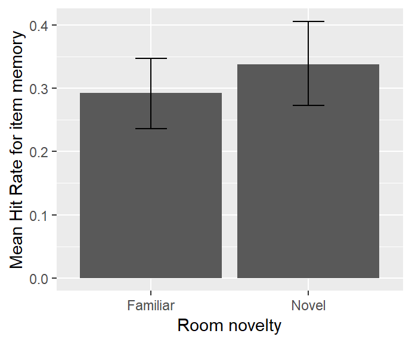

Figure 3. Mean hit rate for recollect response respectively for Familiar and Novel rooms.

```
##
##  Paired t-test
##
## data:  MeanSeenHit by Group
## t = -1.838, df = 39, p-value = 0.07369
## alternative hypothesis: true difference in means is not equal to 0
## 95 percent confidence interval:
##  -0.094813373  0.004535596
## sample estimates:
## mean of the differences
##             -0.04513889
```

## 3.2 Item memory as a function of item order

### 3.2.1 Visualise the data

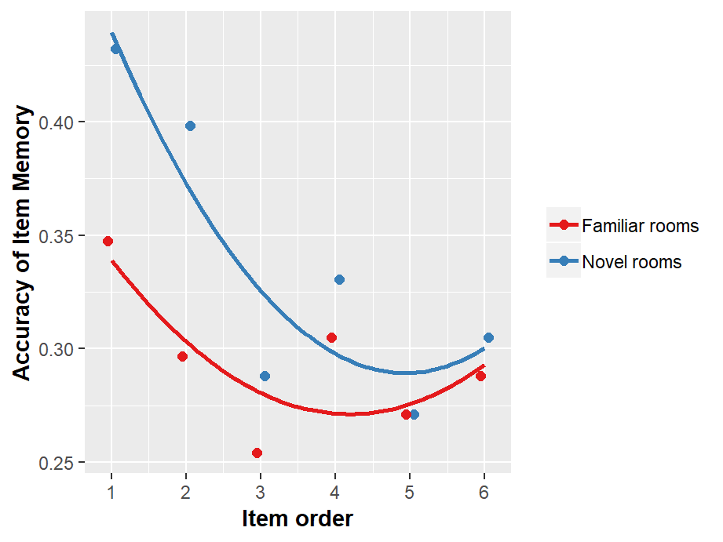

Figure 4. Mean hit rate for seen response at each order (i.e., 1st, 2nd, 3rd, etc), respectively for familiar and novel rooms.

### 3.2.2 Testing novelty effects by fitting mixed models

Build models with item memory accuracy as $y$ and then examine effects of novelty by comparing the models.

- `baseline.item` is the model with only an intercept.
- `order.model.linear.1` is the model with $\small ItemOrder$ included, showing the effects of item order.
- `order.model.linear.2` is the model allowing the slope (i.e., relationship between item memory and item order) varying across participants.
- `order.model.quad.1` and `order.model.quad.2` repectively included $\small ItemOrder^2$ and related random effects.
- `novelty.model.1` is the model with $\small Group$ (i.e., *familiar* and *novel* rooms) included, examining the effects of novelty of the rooms on the intercept (i.e., mean item memory accuracy at the 1st order or overall if no difference in slope).
- `novelty.model.2` is the model with interaction between $\small Group$ and $\small ItemOrder$ included, examining the effects of novelty on how item memory accuracy changes as a function of item order.
- `novelty.model.3` included interaction between $\small Group$ and $\small ItemOrder^2$ for inestigating whether the pattern changes between *familiar* and *novel* groups.

```
##                      Model df      AIC      BIC    logLik   Test  L.Ratio
## baseline.item            1  4 1746.485 1767.507 -869.2424
## order.model.linear.1     2  5 1740.973 1767.251 -865.4867 1 vs 2 7.511521
## order.model.quad.1       3  6 1739.842 1771.376 -863.9210 2 vs 3 3.131334
## novelty.model.1          4  7 1739.024 1775.813 -862.5118 3 vs 4 2.818394
## novelty.model.2          5  8 1739.116 1781.161 -861.5580 4 vs 5 1.907679
## novelty.model.3          6  9 1741.009 1788.309 -861.5043 5 vs 6 0.107331
##                      p-value
## baseline.item
## order.model.linear.1  0.0061
## order.model.quad.1    0.0768
## novelty.model.1       0.0932
## novelty.model.2       0.1672
## novelty.model.3       0.7432
```

#### 3.2.2.1 Parameter estimation for the complete model

```
## Linear mixed-effects model fit by maximum likelihood
##  Data: Curiosity.Recall.Old[!SubjectNo %in% bad.ps.less.strict]
##        AIC      BIC    logLik
##   1741.009 1788.309 -861.5043
##
## Random effects:
##  Formula: ~1 | SubjectNo
##         (Intercept)
## StdDev:   0.1597193
##
##  Formula: ~1 | Group %in% SubjectNo
##         (Intercept)  Residual
## StdDev: 0.009745695 0.4336663
##
## Fixed effects: SeenHit ~ ItemOrder + I(ItemOrder^2) + Group + ItemOrder:Group +      I(ItemOrder^2):Group
##                                Value  Std.Error   DF   t-value p-value
## (Intercept)                0.3875572 0.07593078 1332  5.104085  0.0000
## ItemOrder                 -0.0558111 0.04682097 1332 -1.192012  0.2335
## I(ItemOrder^2)             0.0066586 0.00654769 1332  1.016938  0.3094
## GroupNovel                 0.1372964 0.10123446   39  1.356222  0.1828
## ItemOrder:GroupNovel      -0.0398305 0.06621485 1332 -0.601534  0.5476
## I(ItemOrder^2):GroupNovel  0.0030266 0.00925984 1332  0.326856  0.7438
##  Correlation:
##                           (Intr) ItmOrd I(ItO^2) GrpNvl ItO:GN
## ItemOrder                 -0.878
## I(ItemOrder^2)             0.805 -0.979
## GroupNovel                -0.667  0.658 -0.604
## ItemOrder:GroupNovel       0.621 -0.707  0.692   -0.931
## I(ItemOrder^2):GroupNovel -0.569  0.692 -0.707    0.854 -0.979
##
## Standardized Within-Group Residuals:
##        Min         Q1        Med         Q3        Max
## -1.6309416 -0.7303324 -0.3594163  1.0909720  2.1572953
##
## Number of Observations: 1416
## Number of Groups:
##            SubjectNo Group %in% SubjectNo
##                   40                   80
```

#### 3.2.2.2 Parameter estimation for the optimal model

```
## Linear mixed-effects model fit by maximum likelihood
##  Data: Curiosity.Recall.Old[!SubjectNo %in% bad.ps.less.strict]
##        AIC      BIC    logLik
##   1739.024 1775.813 -862.5118
##
## Random effects:
##  Formula: ~1 | SubjectNo
##         (Intercept)
## StdDev:   0.1597088
##
##  Formula: ~1 | Group %in% SubjectNo
##         (Intercept) Residual
## StdDev: 0.009677789 0.433984
##
## Fixed effects: SeenHit ~ ItemOrder + I(ItemOrder^2) + Group
##                     Value  Std.Error   DF   t-value p-value
## (Intercept)     0.4343089 0.05776727 1334  7.518252  0.0000
## ItemOrder      -0.0757264 0.03310821 1334 -2.287239  0.0223
## I(ItemOrder^2)  0.0081719 0.00463003 1334  1.764981  0.0778
## GroupNovel      0.0437935 0.02320062   39  1.887599  0.0665
##  Correlation:
##                (Intr) ItmOrd I(IO^2
## ItemOrder      -0.816
## I(ItemOrder^2)  0.748 -0.979
## GroupNovel     -0.201  0.000  0.000
##
## Standardized Within-Group Residuals:
##        Min         Q1        Med         Q3        Max
## -1.5693761 -0.7209143 -0.3692786  1.0848881  2.1673927
##
## Number of Observations: 1416
## Number of Groups:
##            SubjectNo Group %in% SubjectNo
##                   40                   80
```

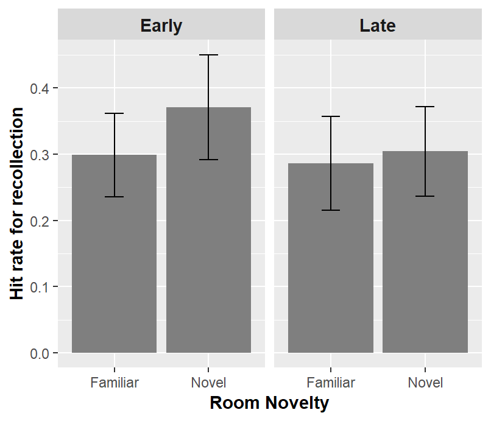

#### 3.2.3.1 Stats on it

```
## Linear mixed-effects model fit by maximum likelihood
##  Data: Curiosity.Recall.Old.Collapsed.Grp[!SubjectNo %in% bad.ps.less.strict]
##         AIC       BIC   logLik
##   -74.30176 -49.70036 45.15088
##
## Random effects:
##  Formula: ~1 | SubjectNo
##         (Intercept)
## StdDev:   0.1582867
##
##  Formula: ~1 | Group %in% SubjectNo
##         (Intercept)
## StdDev:  0.03855752
##
##  Formula: ~1 | ItemOrderType %in% Group %in% SubjectNo
##         (Intercept)   Residual
## StdDev:   0.1366038 0.04347128
##
## Fixed effects: SeenHit ~ Group * ItemOrderType
##                                    Value  Std.Error DF   t-value p-value
## (Intercept)                   0.29861111 0.03474882 78  8.593418  0.0000
## GroupNovel                    0.07222222 0.03361703 39  2.148382  0.0380
## ItemOrderTypeLate            -0.01250000 0.03246328 78 -0.385050  0.7012
## GroupNovel:ItemOrderTypeLate -0.05416667 0.04591001 78 -1.179844  0.2416
##  Correlation:
##                              (Intr) GrpNvl ItmOTL
## GroupNovel                   -0.484
## ItemOrderTypeLate            -0.467  0.483
## GroupNovel:ItemOrderTypeLate  0.330 -0.683 -0.707
##
## Standardized Within-Group Residuals:
##        Min         Q1        Med         Q3        Max
## -0.5359479 -0.1775494 -0.0170921  0.1770284  0.6477224
##
## Number of Observations: 160
## Number of Groups:
##                               SubjectNo
##                                      40
##                    Group %in% SubjectNo
##                                      80
## ItemOrderType %in% Group %in% SubjectNo
##                                     160
```

##### 3.2.3.1.1 Simple effects for the “early” group

```
##
##  Paired t-test
##
## data:  SeenHit by Group
## t = -2.3475, df = 39, p-value = 0.02407
## alternative hypothesis: true difference in means is not equal to 0
## 95 percent confidence interval:
##  -0.134450862 -0.009993583
## sample estimates:
## mean of the differences
##             -0.07222222
```

##### 3.2.3.1.2 Simple effects for the “late” group

```
##
##  Paired t-test
##
## data:  SeenHit by Group
## t = -0.56687, df = 39, p-value = 0.5741
## alternative hypothesis: true difference in means is not equal to 0
## 95 percent confidence interval:
##  -0.08248111  0.04637000
## sample estimates:
## mean of the differences
##             -0.01805556
```

# 4 Curiosity Benefits

We hypothesed that the higher the curiosity rating was, the better the item memory should be.

## 4.1 Mean accuracy of item memory as a function of curiosity rating

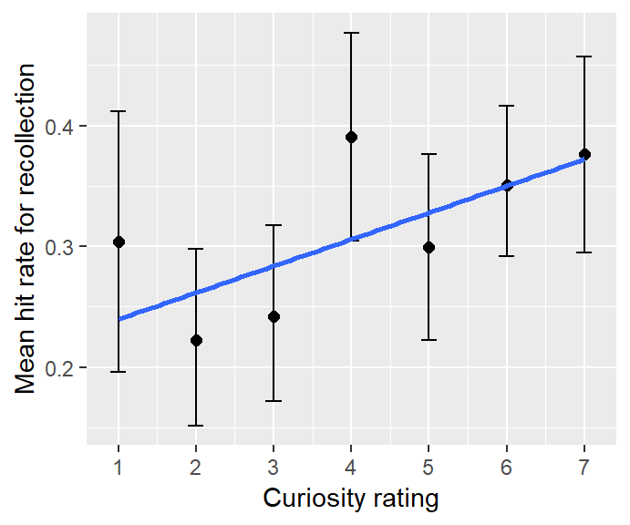

Figure 5. Mean hit rate as a function of curiosity rating.

### 4.1.1 Testing the relationship between mean accuracy of item memory and curiosity rating

Build models with item memory accuracy as $y$ and examine effects of curiosity rating by including it into the model and then comparing the model fits.

- `baseline.rating` is the model with only an intercept, showing no change in item memory as a function of curiosity rating.
- `rating.intercept` is the model with $\small CuriosityRating$ included, showing the effects of curiosity rating.
- `rating.slope` is the model allowing the slope (i.e., relationship between item memory and curiosity rating) varying across participants.

```
##                  Model df       AIC       BIC   logLik   Test  L.Ratio
## baseline.rating      1  3 -58.01060 -47.61910 32.00530
## rating.intercept     2  4 -62.28458 -48.42925 35.14229 1 vs 2 6.273985
## rating.slope         3  6 -62.57440 -41.79141 37.28720 2 vs 3 4.289821
##                  p-value
## baseline.rating
## rating.intercept  0.0123
## rating.slope      0.1171
```

#### 4.1.1.1 Parameter estimates in the complete model

```r
summary(rating.slope)
```

```
## Linear mixed-effects model fit by maximum likelihood
##  Data: OutsideObjectsMemory[!SubjectNo %in% bad.ps.less.strict]
##        AIC       BIC  logLik
##   -62.5744 -41.79141 37.2872
##
## Random effects:
##  Formula: ~1 + CuriosityRating | SubjectNo
##  Structure: General positive-definite, Log-Cholesky parametrization
##                 StdDev     Corr
## (Intercept)     0.19505328 (Intr)
## CuriosityRating 0.03095239 -0.612
## Residual        0.17089421
##
## Fixed effects: SeenHit ~ CuriosityRating
##                      Value  Std.Error  DF  t-value p-value
## (Intercept)     0.23380955 0.04372823 195 5.346878   0.000
## CuriosityRating 0.01722689 0.00806864 195 2.135043   0.034
##  Correlation:
##                 (Intr)
## CuriosityRating -0.783
##
## Standardized Within-Group Residuals:
##         Min          Q1         Med          Q3         Max
## -2.15186988 -0.60206411 -0.06669062  0.54361482  2.58062728
##
## Number of Observations: 236
## Number of Groups: 40
```

#### 4.1.1.2 Plot the model

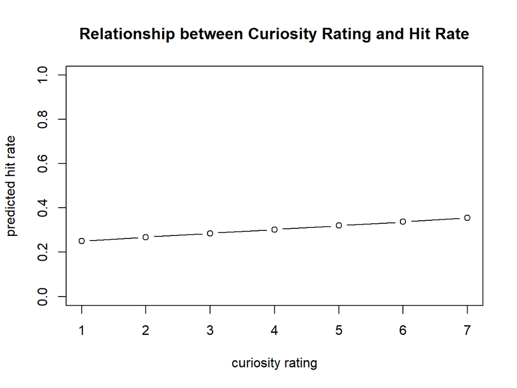

## 4.2 Does the relationship with curiosity rating depend on item order?

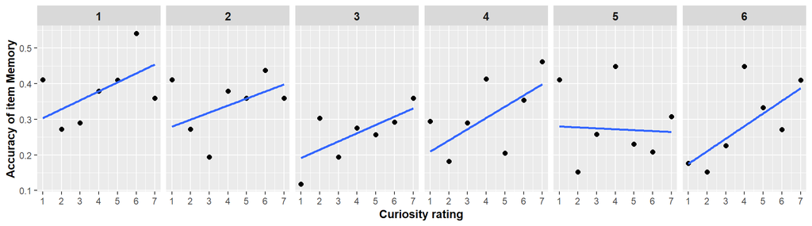

Figure 6. Mean hit rate across participants as a function of curiosity rating for each order at which the item was seen (I.e., 1st, 2nd, 3rd, etc.).

For almost all of the orders, there was a positive trend.

### 4.2.1 Testing the effect of item order

Build models with context memory accuracy as $y$ and examine effects of curiosity rating and item order by comparing the models.

- `item.model.linear.1` is the model with $\small ItemOrder$ included (in addition to $\small CuriosityRating$), showing the effects of item order.
- `item.model.linear.2` is the model allowing the slope (i.e., relationship between item memory and item order) varying across participants.
- `item.model.linear.3` is the model with the interaction between $\small ItemOrders$ and $\small CuriosityRating$ included.
- `item.model.quad.1` and `item.model.quad.2` repectively included $\small ItemOrder^2$ and related random effects.
- `item.model.quad.3` included interaction between $\small ItemOrder^2$ and $\small CuriosityRating$ for inestigating whether the pattern changes as a function of *curiosity rating*.

```r
baseline.item <- lme(SeenHit ~ 1, random = ~ 1|SubjectNo, data = Curiosity.Recall.Old[!SubjectNo %in% bad.ps.less.strict], method = "ML", control = list(msMaxIter = 500, opt = "optim", msVerbose=FALSE), na.action = na.exclude)

rating.intercept <- update(baseline.item, .~. + CuriosityRating)
rating.slope     <- update(rating.intercept, random = ~ 1 + CuriosityRating | SubjectNo)

item.model.linear.1     <- update(rating.slope, .~. + ItemOrder)
item.model.linear.2     <- update(item.model.linear.1, random = ~1+CuriosityRating + ItemOrder|SubjectNo)
item.model.linear.3     <- update(item.model.linear.2, .~. + ItemOrder : CuriosityRating)

item.model.quad.1       <- update(item.model.linear.3, .~. + I(ItemOrder^2))
item.model.quad.2       <- update(item.model.quad.1,   random = ~1+CuriosityRating+ItemOrder+I(ItemOrder^2)|SubjectNo) # excluding this model because singularity issue (perhaps the model was getting too complex to be calculated)
item.model.quad.3       <- update(item.model.quad.2,   .~. + I(ItemOrder^2) : CuriosityRating)

anova(baseline.item, rating.intercept, rating.slope, item.model.linear.1, item.model.linear.2, item.model.linear.3, item.model.quad.1, item.model.quad.2, item.model.quad.3)
```

```
##                     Model df      AIC      BIC    logLik   Test  L.Ratio
## baseline.item           1  3 1745.243 1761.010 -869.6214
## rating.intercept        2  4 1740.743 1761.766 -866.3717 1 vs 2 6.499413
## rating.slope            3  6 1740.706 1772.239 -864.3528 2 vs 3 4.037742
## item.model.linear.1     4  7 1735.105 1771.894 -860.5524 3 vs 4 7.600926
## item.model.linear.2     5 10 1734.072 1786.628 -857.0358 4 vs 5 7.033044
## item.model.linear.3     6 11 1736.067 1793.879 -857.0335 5 vs 6 0.004680
## item.model.quad.1       7 12 1734.848 1797.915 -855.4240 6 vs 7 3.218971
## item.model.quad.2       8 16 1740.100 1824.189 -854.0500 7 vs 8 2.748075
## item.model.quad.3       9 17 1741.723 1831.068 -853.8614 8 vs 9 0.377167
##                     p-value
## baseline.item
## rating.intercept     0.0108
## rating.slope         0.1328
## item.model.linear.1  0.0058
## item.model.linear.2  0.0709
## item.model.linear.3  0.9455
## item.model.quad.1    0.0728
## item.model.quad.2    0.6008
## item.model.quad.3    0.5391
```

#### 4.2.1.1 Parameter estimation for the optimal model

```r
summary(item.model.linear.2 )
```

```
## Linear mixed-effects model fit by maximum likelihood
##  Data: Curiosity.Recall.Old[!SubjectNo %in% bad.ps.less.strict]
##        AIC      BIC    logLik
##   1734.072 1786.628 -857.0358
##
## Random effects:
##  Formula: ~1 + CuriosityRating + ItemOrder | SubjectNo
##  Structure: General positive-definite, Log-Cholesky parametrization
##                 StdDev     Corr
## (Intercept)     0.24378985 (Intr) CrstyR
## CuriosityRating 0.02957138 -0.395
## ItemOrder       0.03109774 -0.649 -0.173
## Residual        0.42774805
##
## Fixed effects: SeenHit ~ CuriosityRating + ItemOrder
##                       Value  Std.Error   DF   t-value p-value
## (Intercept)      0.29790202 0.05489907 1374  5.426358  0.0000
## CuriosityRating  0.01739727 0.00800341 1374  2.173731  0.0299
## ItemOrder       -0.01840226 0.00828906 1374 -2.220065  0.0266
##  Correlation:
##                 (Intr) CrstyR
## CuriosityRating -0.591
## ItemOrder       -0.613 -0.060
##
## Standardized Within-Group Residuals:
##        Min         Q1        Med         Q3        Max
## -1.6910890 -0.6964643 -0.3715112  1.0482223  2.1783964
##
## Number of Observations: 1416
## Number of Groups: 40
```

### 4.2.2 Collapse the order and curiosity rating

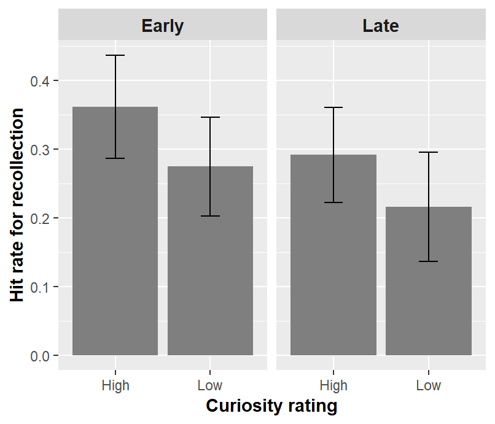

Figure 7. Mean hit rate as a function of item order (Early vs. Late) and curiosity (Low vs. High).

#### 4.2.2.1 Stats on it

```
## Linear mixed-effects model fit by maximum likelihood
##  Data: Curiosity.Recall.Old.Collapsed[!SubjectNo %in% bad.ps.less.strict]
##         AIC       BIC   logLik
##   -36.11197 -11.92093 26.05599
##
## Random effects:
##  Formula: ~1 | SubjectNo
##         (Intercept)
## StdDev:    0.132008
##
##  Formula: ~1 | CuriosityRatingType %in% SubjectNo
##         (Intercept)
## StdDev:  0.07367941
##
##  Formula: ~1 | ItemOrderType %in% CuriosityRatingType %in% SubjectNo
##         (Intercept)   Residual
## StdDev:   0.1543029 0.05574037
##
## Fixed effects: SeenHit ~ CuriosityRatingType * ItemOrderType
##                                               Value  Std.Error DF
## (Intercept)                               0.3618056 0.03574783 74
## CuriosityRatingTypeLow                   -0.0791050 0.04217930 35
## ItemOrderTypeLate                        -0.0698611 0.03717784 74
## CuriosityRatingTypeLow:ItemOrderTypeLate  0.0112191 0.05401815 74
##                                            t-value p-value
## (Intercept)                              10.121049  0.0000
## CuriosityRatingTypeLow                   -1.875445  0.0691
## ItemOrderTypeLate                        -1.879106  0.0642
## CuriosityRatingTypeLow:ItemOrderTypeLate  0.207692  0.8360
##  Correlation:
##                                          (Intr) CrsRTL ItmOTL
## CuriosityRatingTypeLow                   -0.551
## ItemOrderTypeLate                        -0.520  0.441
## CuriosityRatingTypeLow:ItemOrderTypeLate  0.358 -0.640 -0.688
##
## Standardized Within-Group Residuals:
##          Min           Q1          Med           Q3          Max
## -0.719797692 -0.214067834 -0.008323014  0.188266442  0.827644719
##
## Number of Observations: 152
## Number of Groups:
##                                             SubjectNo
##                                                    40
##                    CuriosityRatingType %in% SubjectNo
##                                                    76
## ItemOrderType %in% CuriosityRatingType %in% SubjectNo
##                                                   152
```

### 4.2.3 Try another way to calculate “High” and “Low” curiosity groups

> “High” - higher than mean; “Low” - lower than mean

#### 4.2.3.1 Compare “High” and “Low” groups

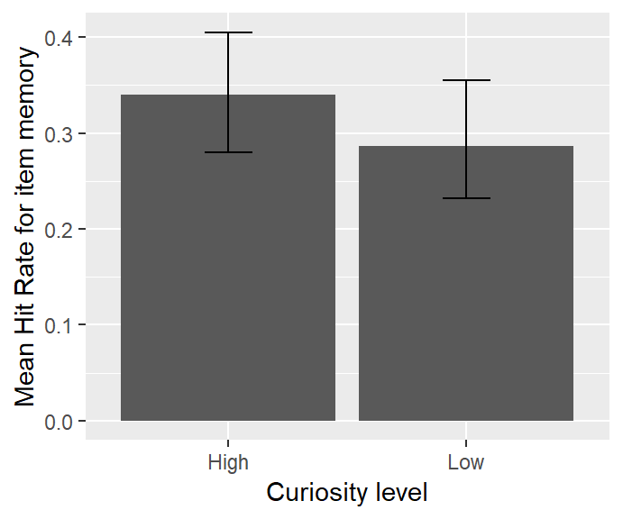

```
##
##  Paired t-test
##
## data:  SeenHit by RatingGroup
## t = 2.0799, df = 39, p-value = 0.04415
## alternative hypothesis: true difference in means is not equal to 0
## 95 percent confidence interval:
##  0.001471108 0.105473336
## sample estimates:
## mean of the differences
##              0.05347222
```

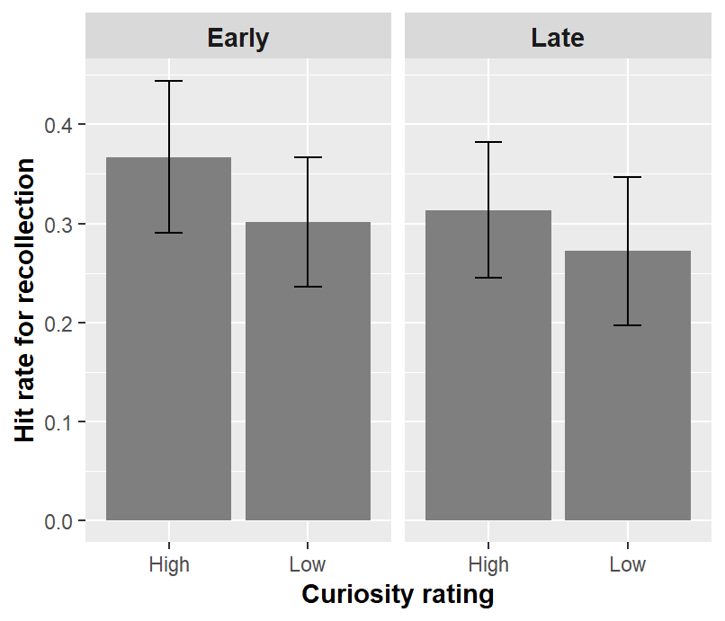

#### 4.2.3.2 Stats on it

```
## Linear mixed-effects model fit by maximum likelihood
##  Data: Curiosity.Recall.Old.Collapsed.Alt[!SubjectNo %in% bad.ps.less.strict]
##         AIC       BIC   logLik
##   -63.20721 -38.60582 39.60361
##
## Random effects:
##  Formula: ~1 | SubjectNo
##         (Intercept)
## StdDev:   0.1573655
##
##  Formula: ~1 | RatingGroup %in% SubjectNo
##         (Intercept)
## StdDev:  0.04077879
##
##  Formula: ~1 | ItemOrderType %in% RatingGroup %in% SubjectNo
##         (Intercept)   Residual
## StdDev:   0.1428369 0.04527919
##
## Fixed effects: SeenHit ~ RatingGroup * ItemOrderType
##                                       Value  Std.Error DF   t-value
## (Intercept)                       0.3670833 0.03540223 78 10.368934
## RatingGroupLow                   -0.0656944 0.03516663 39 -1.868090
## ItemOrderTypeLate                -0.0536111 0.03393250 78 -1.579934
## RatingGroupLow:ItemOrderTypeLate  0.0244444 0.04798780 78  0.509389
##                                  p-value
## (Intercept)                       0.0000
## RatingGroupLow                    0.0693
## ItemOrderTypeLate                 0.1182
## RatingGroupLow:ItemOrderTypeLate  0.6119
##  Correlation:
##                                  (Intr) RtngGL ItmOTL
## RatingGroupLow                   -0.497
## ItemOrderTypeLate                -0.479  0.482
## RatingGroupLow:ItemOrderTypeLate  0.339 -0.682 -0.707
##
## Standardized Within-Group Residuals:
##          Min           Q1          Med           Q3          Max
## -0.703230669 -0.184874046  0.006192257  0.180646750  0.622106187
##
## Number of Observations: 160
## Number of Groups:
##                                     SubjectNo
##                                            40
##                    RatingGroup %in% SubjectNo
##                                            80
## ItemOrderType %in% RatingGroup %in% SubjectNo
##                                           160
```

# 5 Curiosity and novelty

## 5.1 Testing the effects of curiosity rating and novelty together

Build models with item memory accuracy as $y$ and examine effects of curiosity rating and novelty together by including them into the model separately and then comparing the model fits.

```
##                   Model df       AIC       BIC   logLik   Test  L.Ratio
## baseline.rating       1  4 -56.47495 -42.61962 32.23747
## rating.intercept      2  5 -60.31095 -42.99179 35.15547 1 vs 2 5.835998
## rating.slope          3  9 -56.56845 -25.39396 37.28422 2 vs 3 4.257502
## novelty.model.1       4 10 -54.60237 -19.96405 37.30118 3 vs 4 0.033921
## interaction.model     5 11 -53.38208 -15.27993 37.69104 4 vs 5 0.779715
##                   p-value
## baseline.rating
## rating.intercept   0.0157
## rating.slope       0.3723
## novelty.model.1    0.8539
## interaction.model  0.3772
```

### 5.1.1 Check the complete model

```
## Linear mixed-effects model fit by maximum likelihood
##  Data: OutsideObjectsMemory[!SubjectNo %in% bad.ps.less.strict]
##         AIC       BIC   logLik
##   -53.38208 -15.27993 37.69104
##
## Random effects:
##  Formula: ~1 + CuriosityRating | SubjectNo
##  Structure: General positive-definite, Log-Cholesky parametrization
##                 StdDev     Corr
## (Intercept)     0.19868842 (Intr)
## CuriosityRating 0.03246124 -0.629
##
##  Formula: ~1 + CuriosityRating | Group %in% SubjectNo
##  Structure: General positive-definite, Log-Cholesky parametrization
##                 StdDev       Corr
## (Intercept)     0.0026047541 (Intr)
## CuriosityRating 0.0001188406 -0.009
## Residual        0.1697943612
##
## Fixed effects: SeenHit ~ CuriosityRating + Group + CuriosityRating:Group
##                                  Value  Std.Error  DF   t-value p-value
## (Intercept)                 0.20969791 0.05329599 154  3.934591  0.0001
## CuriosityRating             0.02532564 0.01404850 154  1.802729  0.0734
## GroupNovel                  0.09041915 0.11479717  39  0.787643  0.4357
## CuriosityRating:GroupNovel -0.01966138 0.02194831 154 -0.895804  0.3718
##  Correlation:
##                            (Intr) CrstyR GrpNvl
## CuriosityRating            -0.828
## GroupNovel                 -0.280  0.286
## CuriosityRating:GroupNovel  0.425 -0.524 -0.942
##
## Standardized Within-Group Residuals:
##        Min         Q1        Med         Q3        Max
## -2.1268677 -0.5902655 -0.0577787  0.5658924  2.5957289
##
## Number of Observations: 236
## Number of Groups:
##            SubjectNo Group %in% SubjectNo
##                   40                   80
```

## 5.2 What about the other way around

```
##                   Model df       AIC       BIC   logLik   Test  L.Ratio
## baseline.rating       1  4 -56.47495 -42.61962 32.23747
## novelty.model.1       2  5 -57.43929 -40.12013 33.71964 1 vs 2 2.964340
## rating.model.1        3  6 -58.39208 -37.60909 35.19604 2 vs 3 2.952790
## rating.model.2        4 10 -54.60237 -19.96405 37.30118 3 vs 4 4.210292
## interaction.model     5 11 -53.38208 -15.27993 37.69104 4 vs 5 0.779715
##                   p-value
## baseline.rating
## novelty.model.1    0.0851
## rating.model.1     0.0857
## rating.model.2     0.3783
## interaction.model  0.3772
```

### 5.2.1 Check the complete model

```
## Linear mixed-effects model fit by maximum likelihood
##  Data: OutsideObjectsMemory[!SubjectNo %in% bad.ps.less.strict]
##         AIC       BIC   logLik
##   -53.38208 -15.27993 37.69104
##
## Random effects:
##  Formula: ~1 + CuriosityRating | SubjectNo
##  Structure: General positive-definite, Log-Cholesky parametrization
##                 StdDev     Corr
## (Intercept)     0.19868842 (Intr)
## CuriosityRating 0.03246124 -0.629
##
##  Formula: ~1 + CuriosityRating | Group %in% SubjectNo
##  Structure: General positive-definite, Log-Cholesky parametrization
##                 StdDev       Corr
## (Intercept)     0.0026047539 (Intr)
## CuriosityRating 0.0001188406 -0.009
## Residual        0.1697943612
##
## Fixed effects: SeenHit ~ Group + CuriosityRating + Group:CuriosityRating
##                                  Value  Std.Error  DF   t-value p-value
## (Intercept)                 0.20969791 0.05329599 154  3.934591  0.0001
## GroupNovel                  0.09041915 0.11479717  39  0.787643  0.4357
## CuriosityRating             0.02532564 0.01404850 154  1.802729  0.0734
## GroupNovel:CuriosityRating -0.01966138 0.02194831 154 -0.895804  0.3718
##  Correlation:
##                            (Intr) GrpNvl CrstyR
## GroupNovel                 -0.280
## CuriosityRating            -0.828  0.286
## GroupNovel:CuriosityRating  0.425 -0.942 -0.524
##
## Standardized Within-Group Residuals:
##        Min         Q1        Med         Q3        Max
## -2.1268677 -0.5902655 -0.0577787  0.5658924  2.5957289
##
## Number of Observations: 236
## Number of Groups:
##            SubjectNo Group %in% SubjectNo
##                   40                   80
```

## 5.3 Check the collapsed data

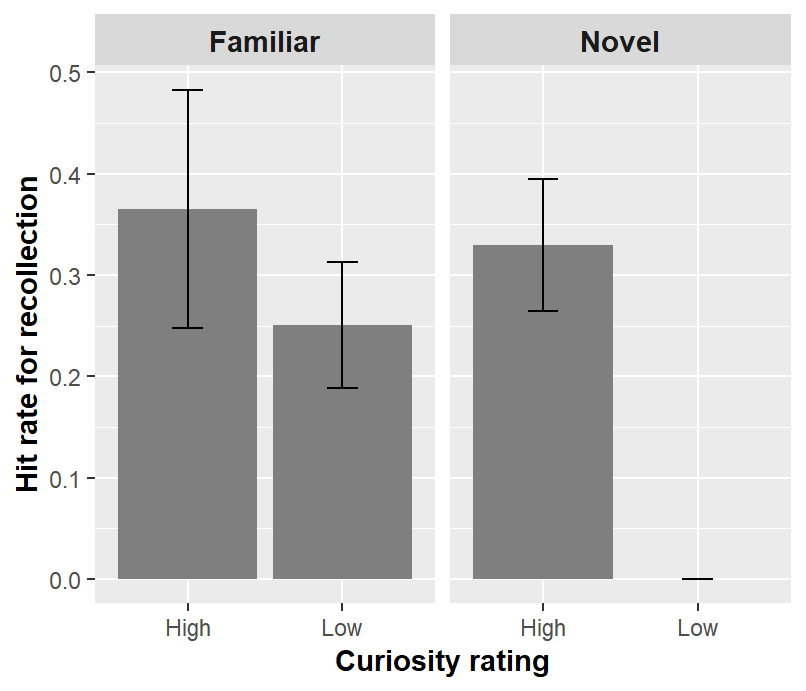

#### 5.3.0.1 Stats on it

```
## Linear mixed-effects model fit by maximum likelihood
##  Data: Curiosity.Recall.Old.Collapsed.Interaction[!SubjectNo %in% bad.ps.less.strict]
##         AIC       BIC   logLik
##   -45.32232 -25.23544 30.66116
##
## Random effects:
##  Formula: ~1 | SubjectNo
##         (Intercept)
## StdDev:   0.1287183
##
##  Formula: ~1 | CuriosityRatingType %in% SubjectNo
##         (Intercept)
## StdDev:   0.1024441
##
##  Formula: ~1 | Group %in% CuriosityRatingType %in% SubjectNo
##         (Intercept)   Residual
## StdDev:  0.09092163 0.04220837
##
## Fixed effects: SeenHit ~ CuriosityRatingType * Group
##                                        Value  Std.Error DF   t-value
## (Intercept)                        0.3255099 0.04341829 39  7.497067
## CuriosityRatingTypeLow            -0.0664458 0.04610082 35 -1.441316
## GroupNovel                         0.0043512 0.03795021 13  0.114656
## CuriosityRatingTypeLow:GroupNovel -0.2221456 0.10149745 13 -2.188682
##                                   p-value
## (Intercept)                        0.0000
## CuriosityRatingTypeLow             0.1584
## GroupNovel                         0.9105
## CuriosityRatingTypeLow:GroupNovel  0.0475
##  Correlation:
##                                   (Intr) CrsRTL GrpNvl
## CuriosityRatingTypeLow            -0.738
## GroupNovel                        -0.715  0.688
## CuriosityRatingTypeLow:GroupNovel  0.274 -0.326 -0.382
##
## Standardized Within-Group Residuals:
##          Min           Q1          Med           Q3          Max
## -0.621528465 -0.220815430 -0.005424137  0.192421464  0.631334788
##
## Number of Observations: 91
## Number of Groups:
##                                     SubjectNo
##                                            40
##            CuriosityRatingType %in% SubjectNo
##                                            76
## Group %in% CuriosityRatingType %in% SubjectNo
##                                            91
```

### 5.3.1 Alternative way to collapse data

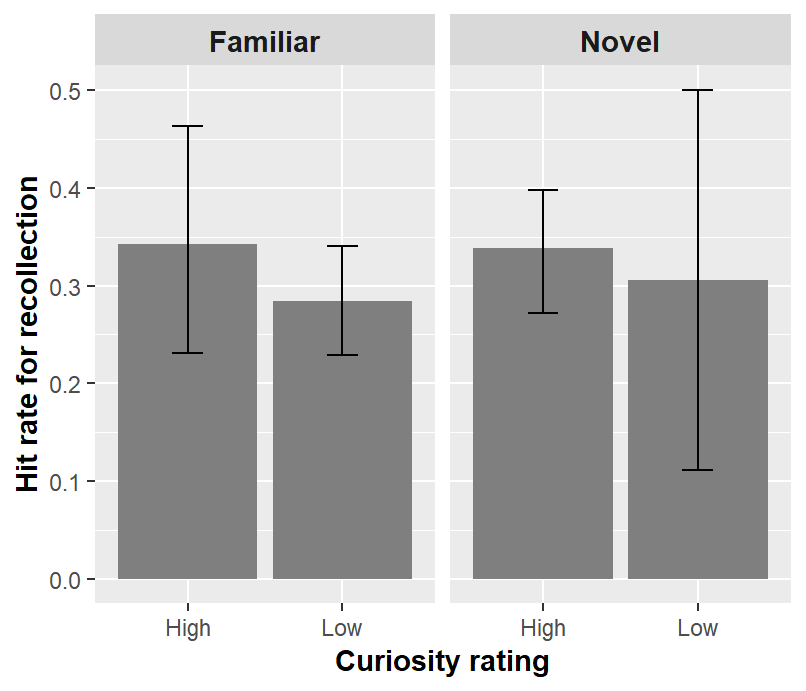

```
## Linear mixed-effects model fit by maximum likelihood
##  Data: Curiosity.Recall.Old.Collapsed.Alt.Interaction[!SubjectNo %in%      bad.ps.less.strict]
##         AIC       BIC   logLik
##   -50.23194 -29.80093 33.11597
##
## Random effects:
##  Formula: ~1 | SubjectNo
##         (Intercept)
## StdDev:   0.1543493
##
##  Formula: ~1 | RatingGroup %in% SubjectNo
##         (Intercept)
## StdDev:  0.06388824
##
##  Formula: ~1 | Group %in% RatingGroup %in% SubjectNo
##         (Intercept)   Residual
## StdDev:   0.1018092 0.03935519
##
## Fixed effects: SeenHit ~ RatingGroup * Group
##                                Value  Std.Error DF   t-value p-value
## (Intercept)                0.3533732 0.05178970 39  6.823234  0.0000
## RatingGroupLow            -0.0686510 0.04977820 39 -1.379138  0.1757
## GroupNovel                -0.0144843 0.04759005 13 -0.304356  0.7657
## RatingGroupLow:GroupNovel  0.0542271 0.07843336 13  0.691378  0.5015
##  Correlation:
##                           (Intr) RtngGL GrpNvl
## RatingGroupLow            -0.799
## GroupNovel                -0.793  0.825
## RatingGroupLow:GroupNovel  0.555 -0.657 -0.687
##
## Standardized Within-Group Residuals:
##          Min           Q1          Med           Q3          Max
## -0.660788341 -0.181005658  0.008927672  0.184353321  0.584299080
##
## Number of Observations: 95
## Number of Groups:
##                             SubjectNo
##                                    40
##            RatingGroup %in% SubjectNo
##                                    80
## Group %in% RatingGroup %in% SubjectNo
##                                    95
```

# 6 Curiosity effects in the *Novel* group

## 6.1 Mean accuracy of item memory as a function of curiosity rating

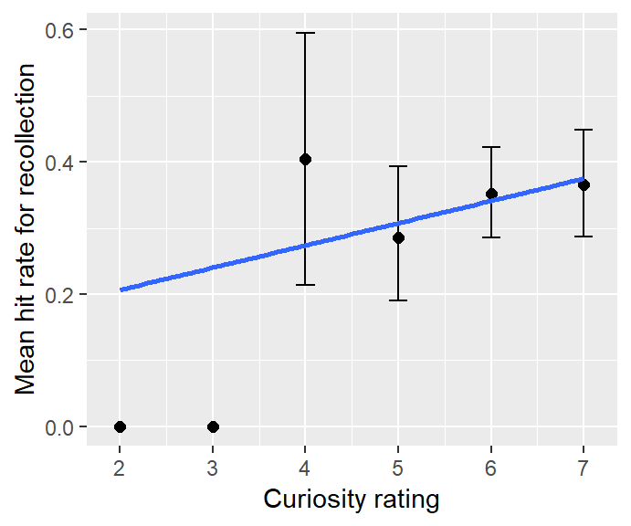